# Project: Identify Customer Segments

## Findings

Following three themes have been identified from the clustering analysis.These represent segments of the population that are popular with the mail order company and form major components of the population.

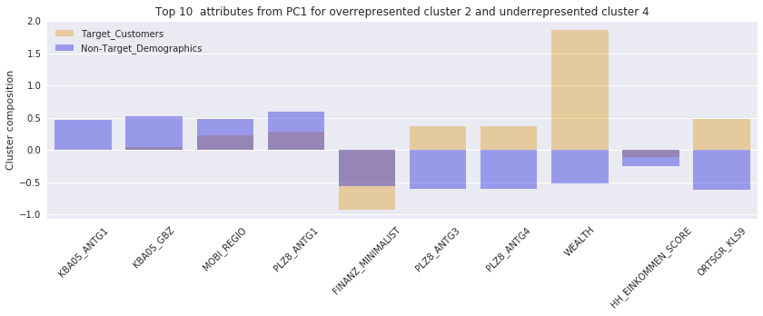

```python
#Consider the top five positive and negative loadings from Principal Component1 in both the clusters.
PC1=pca_weights.iloc[0][1:].sort_values(ascending=False)[-5:].index.tolist() + pca_weights.iloc[0][1:].sort_values(ascending=False)[:5].index.tolist()
pc1_df=cl_c_df[PC1]
clu_ovr_pc1 = pc1_df.iloc[0]
clu_undr_pc1 = pc1_df.iloc[1]
plt.figure(figsize=(14,4))
sns.barplot(y=clu_ovr_pc1, x=pc1_df.columns.tolist(),label="Target_Customers",color='orange',alpha=0.4 )
sns.barplot(y=clu_undr_pc1, x=pc1_df.columns.tolist(),label="Non-Target_Demographics",color='blue',alpha=0.4)
plt.ylabel('Cluster composition')
plt.xticks(rotation=45)
plt.title('Top 10  attributes from PC1 for overrepresented cluster 2 and underrepresented cluster 4')
plt.legend();
```

**Theme - Wealth, family and community size, corresponding living space and mobility.**

The over represented customer demography is wealthy belonging to large families of 6-10,do not have low financial interest, belong to large communities. The under represented general population or the non-target population is mainly smaller families : 1-2 , live in smaller houses,earning levels are on the lower side and move around a lot. There are also some big wealthy families in large communities and are mobile who are not the favourites of the mail-order company.

KBA05_GBZ -Refers to number of buildings, KBA05_ANTG1 and KBA05_ANTG1 - smaller families : 1-2.These families are likely more mobile or have higher movement pattern and have low financial interest.

HH_EINKOMMEN_SCORE talks about the estimated net income.We see it on a negative scale but the Wealth indicator is a large positive value?How is that interpreted? why would the people reveal the net income details to a mail-order company?

PLZ8_ANTG3 and PLZ8_ANTG4 describes the share of the number of 6-10 family houses and 10+ family houses -These are on positive scale indicating, they are more compared to the smaller families.PLZ8_ANTG1 - Number of 1-2 family houses in the PLZ8 region.

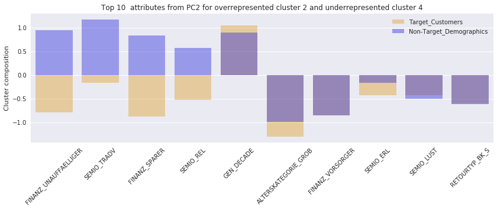

```python
PC2=pca_weights.iloc[1][1:].sort_values(ascending=False)[-5:].index.tolist() + pca_weights.iloc[1][1:].sort_values(ascending=False)[:5].index.tolist()
pc2_df=cl_c_df[PC2]
clu_ovr_pc2 = pc2_df.iloc[0]
clu_undr_pc2 = pc2_df.iloc[1]
plt.figure(figsize=(14,4))
sns.barplot(y=clu_ovr_pc2, x=pc2_df.columns.tolist(),label="Target_Customers",color='orange',alpha=0.4 )
sns.barplot(y=clu_undr_pc2, x=pc2_df.columns.tolist(),label="Non-Target_Demographics",color='blue',alpha=0.4)
plt.ylabel('Cluster composition')
plt.xticks(rotation=45)
plt.title('Top 10  attributes from PC2 for overrepresented cluster 2 and underrepresented cluster 4')
plt.legend();
```

**Theme - Financial typology, personality, return type,generation and age group**

The target cutsomers are active /regular shoppers who belong to the pleasure-seeking younger crowd. High consumption, low focus on saving money and low financial preparedness,non-religious and non-traditional minded are the favourites for the mail-order company.

The non-target population is traditional,dutiful,religious and thrifty.

The features of the above population are identified by - Personality type :SEMIO_TRADV - being tradional-minded , SEMIO_ERL - event-oriented, SEMIO_REL - religious,SEMIO_LUST: sensual-minded Financial typology :FINANZ_SPARER - money-saver ,FINANZ_UNAUFFAELLIGER: inconspicuous GEN_DECADE - generation by decade RETOURTYP_BK_S - Return type

Company's not so populat are those not willing to splurge. The active returners are likely to explore the company's products.

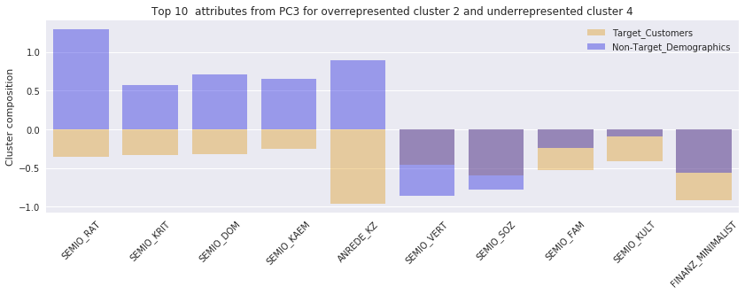

```python
PC3=pca_weights.iloc[2][1:].sort_values(ascending=False)[-5:].index.tolist() + pca_weights.iloc[2][1:].sort_values(ascending=False)[:5].index.tolist()
pc3_df=cl_c_df[PC3]
clu_ovr_pc3 = pc3_df.iloc[0]
clu_undr_pc3 = pc3_df.iloc[1]
plt.figure(figsize=(14,4))
sns.barplot(y=clu_ovr_pc3, x=pc3_df.columns.tolist(),label="Target_Customers",color='orange',alpha=0.4 )
sns.barplot(y=clu_undr_pc3, x=pc3_df.columns.tolist(),label="Non-Target_Demographics",color='blue',alpha=0.4)
plt.ylabel('Cluster composition')
plt.xticks(rotation=45)
plt.title('Top 10  attributes from PC3 for overrepresented cluster 2 and underrepresented cluster 4')
plt.legend();
```

**Theme - Familial Personality type**

Personality profiling will help tailor their marketing and sales strategy.